# Projet Statistiques Bayésiennes : Données Spotify

## Création de vecteurs pour l’étude Bayésienne

```r
danceability_like <- data$danceability[data$label == "like"]
danceability_dislike <- data$danceability[data$label == "dislike"]

energy_like <- data$energy[data$label == "like"]
energy_dislike <- data$energy[data$label == "dislike"]

key_like <- data$key[data$label == "like"]
key_dislike <- data$key[data$label == "dislike"]


loudness_like <- data$loudness[data$label == "like"]
loudness_dislike<- data$loudness[data$label == "dislike"]

mode_like <- data$mode[data$label == "like"]
mode_dislike <- data$mode[data$label == "dislike"]

speechiness_like <- data$speechiness[data$label == "like"]
speechiness_dislike <- data$speechiness[data$label == "dislike"]


acousticness_like=data$acousticness[data$label == "like"]
acousticness_dislike=data$acousticness[data$label == "dislike"]

instrumentalness_like=data$instrumentalness[data$label == "like"]
instrumentalness_dislike=data$instrumentalness[data$label == "dislike"]

liveness_like=data$liveness[data$label == "like"]
liveness_dislike=data$liveness[data$label == "dislike"]

valence_like <- data$valence[data$label == "like"]
valence_dislike <- data$valence[data$label == "dislike"]

tempo_like <-  data$tempo[ data$label == "like"]
tempo_dislike <-  data$tempo[ data$label == "dislike"]

duration_like <- data$duration[data$label == "like"]
duration_dislike <- data$duration[data$label == "dislike"]

time_signature_like <- data$time_signature[data$label == "like"]
time_signature_dislike <- data$time_signature[data$label == "dislike"]
```

## Etude de corrélation

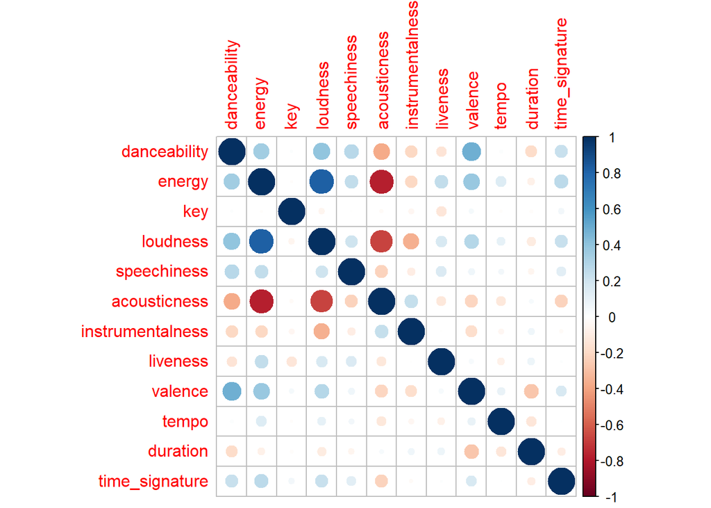

```r
correlation_matrix <- cor(data[,-c(5,14)])
corrplot(correlation_matrix, method = "circle")
```

# 1- Variable : danceability

### Modèle

```r
model_string <- "
model {
  # Number of successes
  for (i in 1:n1){
    y1[i] ~ dnorm(mu1, sigma1)
  }
  for (i in 1:n2){
    y2[i] ~ dnorm(mu2, sigma2)
  }

  mu1 ~ dunif(0, 1)
  mu2 ~ dunif(0, 1)
  sigma1 ~ dunif(0, 1)
  sigma2 ~ dunif(0, 1)
}
"
y1 <- danceability_like
y2 <- danceability_dislike
data_list <- list(y1 = y1, y2 = y2, n1 = length(y1), n2 = length(y2))

jags_samples <- run.jags(model = model_string, data = data_list, monitor = c("mu1", "mu2", "sigma1", "sigma2"))
```

```
## Compiling rjags model...
## Calling the simulation using the rjags method...
## Adapting the model for 1000 iterations...
## Burning in the model for 4000 iterations...
## Running the model for 10000 iterations...
## Simulation complete
## Calculating summary statistics...
## Calculating the Gelman-Rubin statistic for 4 variables....
## Finished running the simulation
```

```r
jags_samples
```

```
##
## JAGS model summary statistics from 20000 samples (chains = 2; adapt+burnin = 5000):
##
##        Lower95  Median Upper95    Mean        SD Mode      MCerr MC%ofSD SSeff
## mu1    0.40802 0.51805 0.63241 0.51786  0.057026   -- 0.00051481     0.9 12270
## mu2    0.52138  0.6597 0.80506 0.65972  0.072163   -- 0.00065941     0.9 11976
## sigma1 0.97982 0.99527       1 0.99325 0.0066821   -- 0.00010708     1.6  3894
## sigma2 0.96962 0.99296       1 0.98988  0.010024   -- 0.00016215     1.6  3821
##
##             AC.10   psrf
## mu1     0.0052382 1.0002
## mu2    -0.0097579 1.0001
## sigma1    0.01773 1.0004
## sigma2   0.028216 1.0002
##
## Total time taken: 14.2 seconds
```

### Interprétation

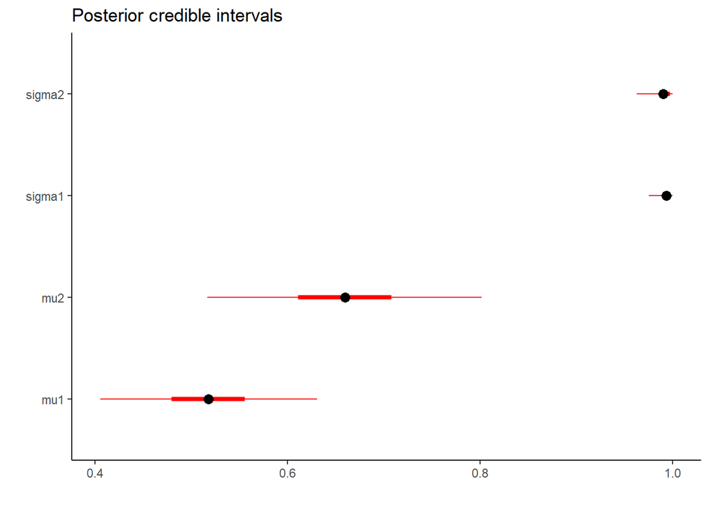

```r
plot_credible_intervals(jags_samples)
```

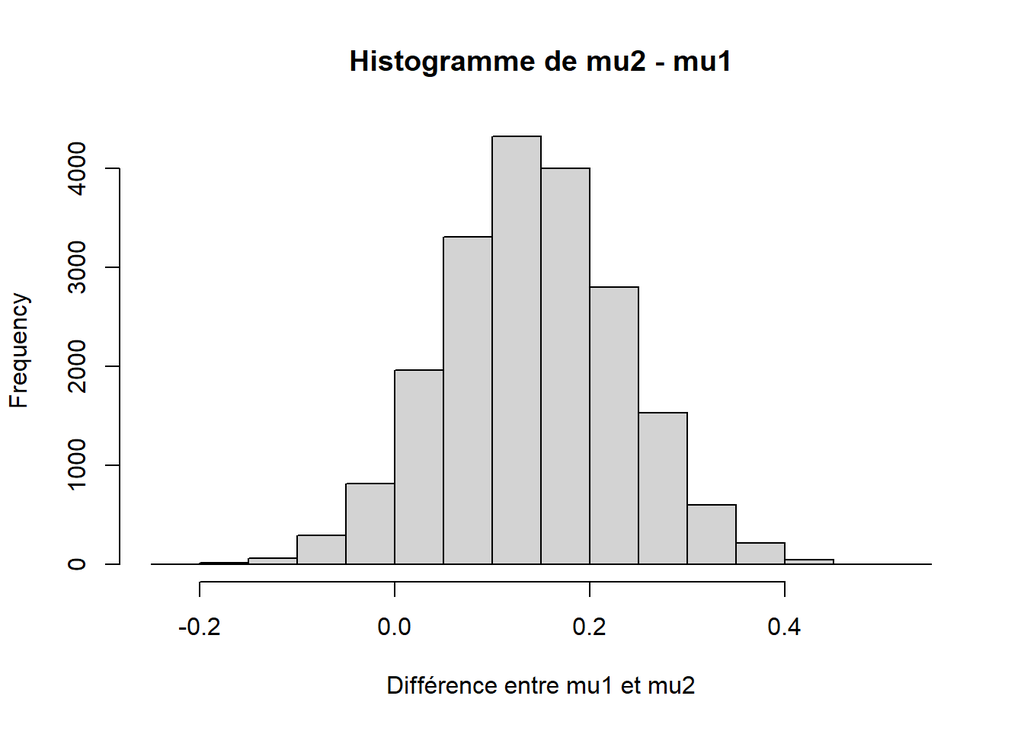

```r
jags_samples_df <- as.data.frame(as.mcmc(jags_samples))

mu_diff <- jags_samples_df$mu2 - jags_samples_df$mu1

hist(mu_diff, main = "Histogramme de mu2 - mu1", xlab = "Différence entre mu1 et mu2")
```

```r
mean(mu_diff > 0)
```

```
## [1] 0.94035
```

# 2- Variable : energy

### Modèle

```r
model_string <- "
model {
  # Number of successes
  for (i in 1:n1){
    y1[i] ~ dnorm(mu1, sigma1)
  }
  for (i in 1:n2){
    y2[i] ~ dnorm(mu2, sigma2)
  }

  mu1 ~ dunif(0, 1)
  mu2 ~ dunif(0, 1)
  sigma1 ~ dunif(0, 1)
  sigma2 ~ dunif(0, 1)
}
"
y1 <- energy_like
y2 <- energy_dislike
data_list <- list(y1 = y1, y2 = y2, n1 = length(y1), n2 = length(y2))

jags_samples <- run.jags(model = model_string, data = data_list, monitor = c("mu1", "mu2", "sigma1", "sigma2"))
```

```
## Compiling rjags model...
## Calling the simulation using the rjags method...
## Adapting the model for 1000 iterations...
## Burning in the model for 4000 iterations...
## Running the model for 10000 iterations...
## Simulation complete
## Calculating summary statistics...
## Calculating the Gelman-Rubin statistic for 4 variables....
## Finished running the simulation
```

```r
jags_samples
```

```
##
## JAGS model summary statistics from 20000 samples (chains = 2; adapt+burnin = 5000):
##
##        Lower95  Median Upper95    Mean        SD Mode      MCerr MC%ofSD SSeff
## mu1    0.38493 0.49642 0.60953 0.49592  0.057169   -- 0.00049899     0.9 13126
## mu2    0.60468 0.73985 0.88525  0.7395  0.071472   -- 0.00062894     0.9 12914
## sigma1 0.97906 0.99509       1 0.99294 0.0069754   -- 0.00011422     1.6  3730
## sigma2 0.96903 0.99277       1 0.98961  0.010167   -- 0.00016237     1.6  3920
##
##              AC.10    psrf
## mu1    -0.00056428  1.0009
## mu2     -0.0023263       1
## sigma1    0.019629 0.99996
## sigma2    0.019983  1.0006
##
## Total time taken: 14.7 seconds
```

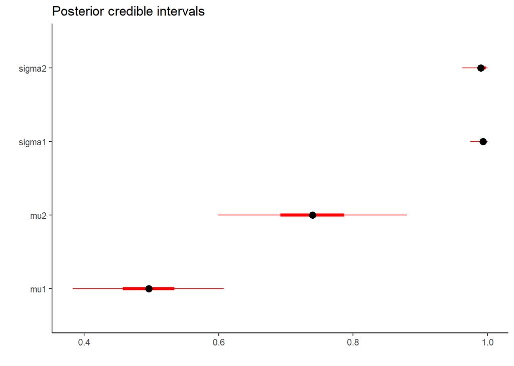

```r
plot_credible_intervals(jags_samples)
```

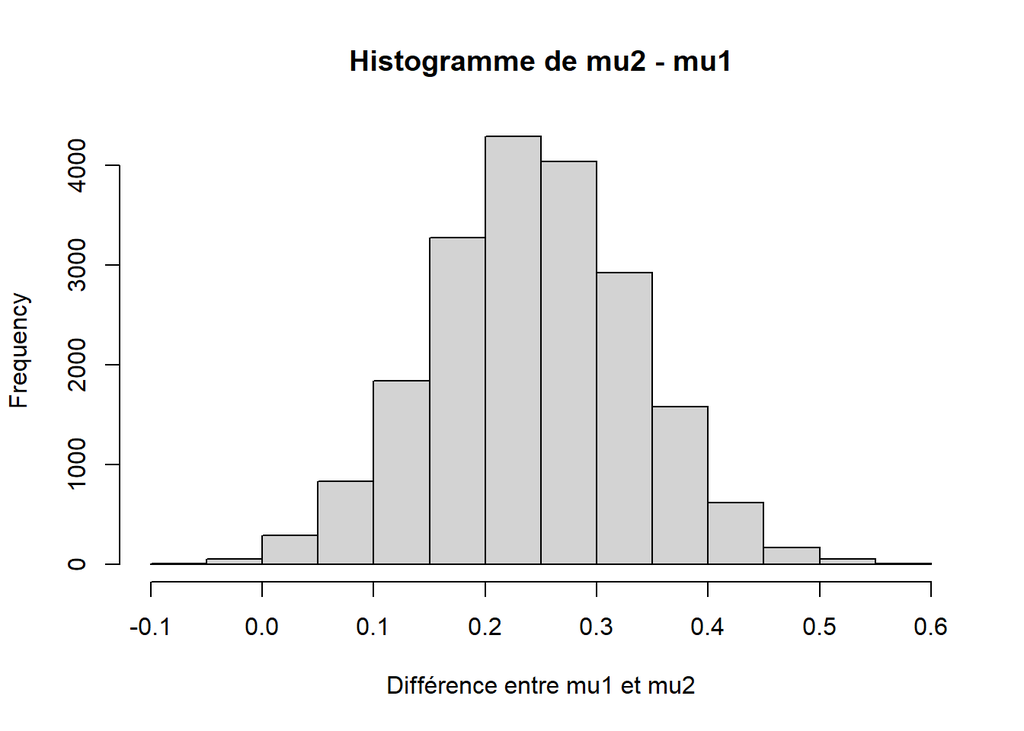

```r
jags_samples_df <- as.data.frame(as.mcmc(jags_samples))

mu_diff <- jags_samples_df$mu2 - jags_samples_df$mu1

hist(mu_diff, main = "Histogramme de mu2 - mu1", xlab = "Différence entre mu1 et mu2")
```

```r
mean(mu_diff > 0)
```

```
## [1] 0.9966
```

# 3- Variable : key

### Modèle

```r
model_string <- "
model {
  # Number of successes
  for (i in 1:n1){
    y1[i] ~ dpois(lambda1)
  }
  for (i in 1:n2){
    y2[i] ~ dpois(lambda2)
  }

  lambda1 ~ dunif(1, 4)
  lambda2 ~ dunif(1, 6)
}
"
y1 <- key_like
y2 <- key_dislike
data_list <- list(y1 = y1, y2 = y2, n1 = length(y1), n2 = length(y2))

jags_samples <- run.jags(model = model_string, data = data_list, monitor = c("lambda1", "lambda2"))
```

```
## Compiling rjags model...
## Calling the simulation using the rjags method...
## Adapting the model for 1000 iterations...
## Burning in the model for 4000 iterations...
## Running the model for 10000 iterations...
## Simulation complete
## Calculating summary statistics...
## Calculating the Gelman-Rubin statistic for 2 variables....
## Finished running the simulation
```

```r
jags_samples
```

```
##
## JAGS model summary statistics from 20000 samples (chains = 2; adapt+burnin = 5000):
##
##         Lower95 Median Upper95   Mean       SD Mode      MCerr MC%ofSD SSeff
## lambda1  3.9525 3.9886       4  3.984 0.015518   -- 0.00023968     1.5  4192
## lambda2  4.4756 4.7801  5.0982 4.7819  0.15708   --   0.001472     0.9 11387
##
##              AC.10   psrf
## lambda1  -0.001739 1.0012
## lambda2 -0.0041769 1.0002
##
## Total time taken: 5.7 seconds
```

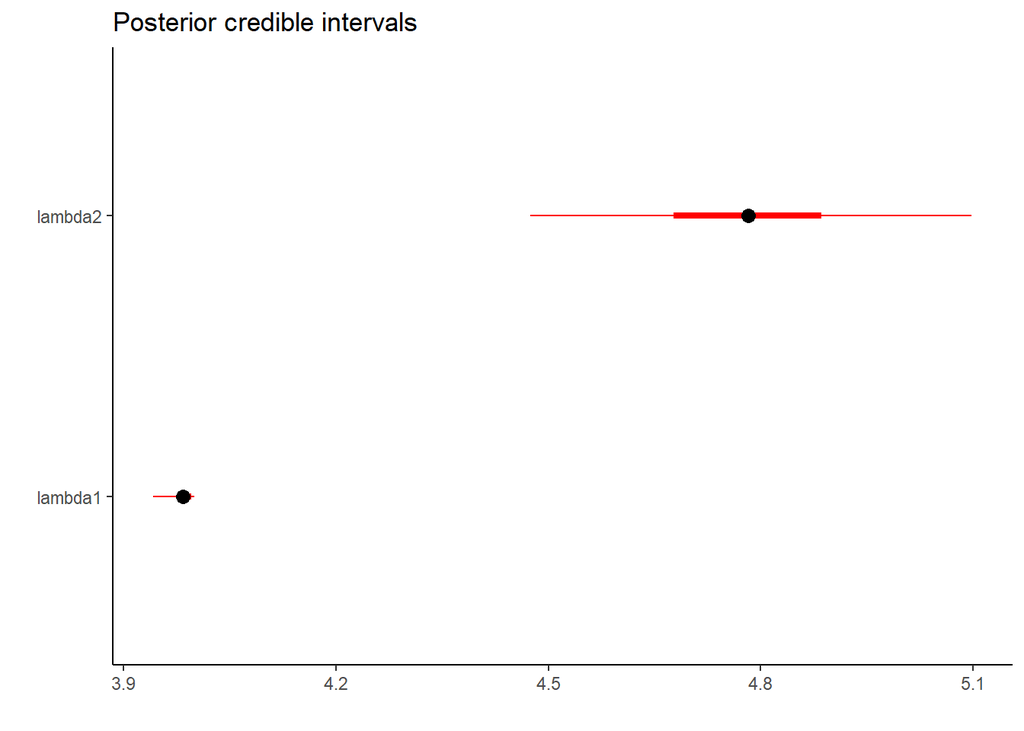

```r
plot_credible_intervals(jags_samples)
```

### Interprétation

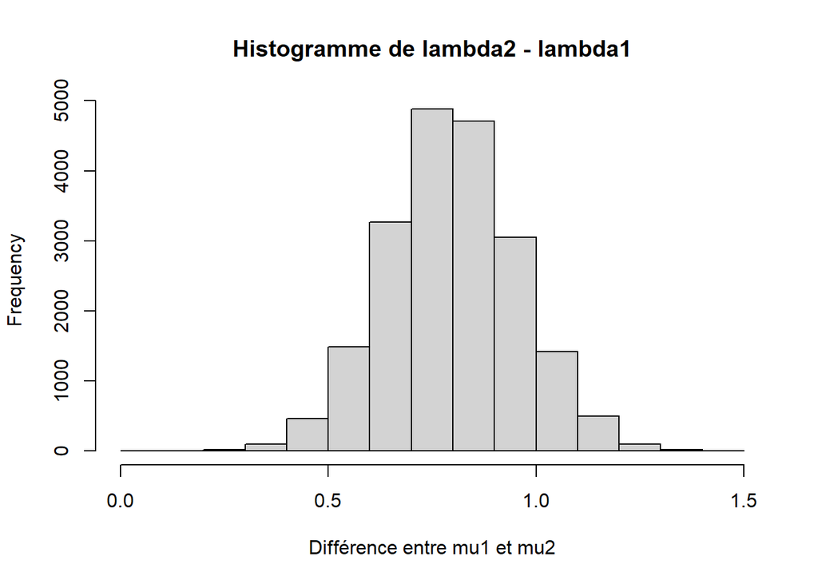

```r
jags_samples_df <- as.data.frame(as.mcmc(jags_samples))

mu_diff <- jags_samples_df$lambda2 - jags_samples_df$lambda1

hist(mu_diff, main = "Histogramme de lambda2 - lambda1", xlab = "Différence entre mu1 et mu2")
```

```r
mean(mu_diff > 0)
```

```
## [1] 1
```

# 4- Variable : loudness

**Description :** Les valeurs d’intensité sonore sont moyennées sur l’ensemble de la piste et sont utiles pour comparer le volume relatif des pistes.L’intensité sonore est la qualité d’un son qui est la principale corrélat psychologique de la force physique (amplitude). Les valeurs varient généralement entre -60 et 0 dB.

## Modèle

```r
model_string_loudness <- "
model {
  # Number of successes
  for (i in 1:n1){
    y1[i] ~ dnorm(mu1, sigma1)
  }
  for (i in 1:n2){
    y2[i] ~ dnorm(mu2, sigma2)
  }

  mu1 ~ dunif(-40, 0)
  mu2 ~ dunif(-40, 0)

  sigma1 ~ dunif(0, 70)
  sigma2 ~ dunif(0, 70)
}
"


y1 = loudness_like
y2 = loudness_dislike
# Créer une liste de données pour JAGS
data_list <- list(y1 = y1, y2 = y2 ,n1 = length(y1), n2 = length(y2))

# Exécuter le modèle et extraire les échantillons postérieurs
jags_samples <- run.jags(model = model_string_loudness, data = data_list, monitor = c("mu1", "mu2","sigma1","sigma2"))
```

```
## Compiling rjags model...
## Calling the simulation using the rjags method...
## Adapting the model for 1000 iterations...
## Burning in the model for 4000 iterations...
## Running the model for 10000 iterations...
## Simulation complete
## Calculating summary statistics...
## Calculating the Gelman-Rubin statistic for 4 variables....
## Finished running the simulation
```

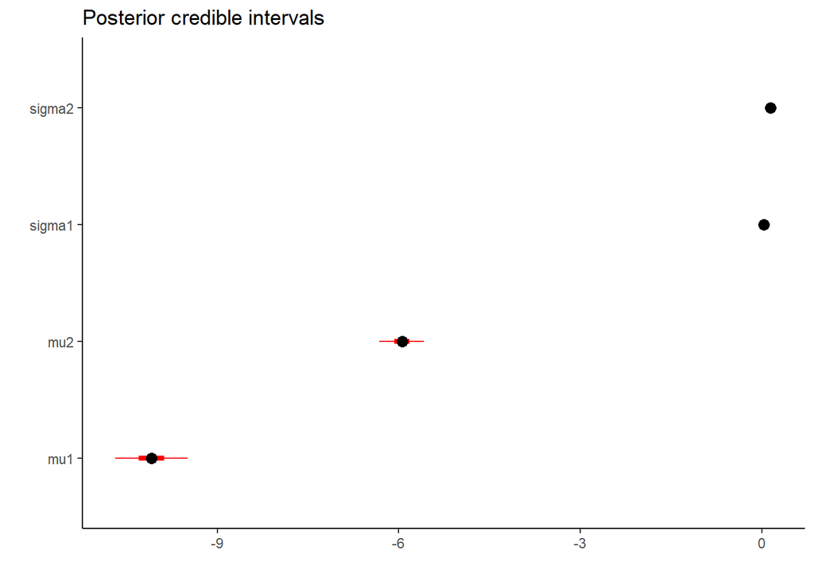

```r
# Visualiser les résultats
plot_credible_intervals(jags_samples)
```

## Interprétation

```r
s <- as.data.frame(jags_samples$mcmc %>% lapply(as_tibble) %>% bind_rows())
# The probability that the rate theta1 is smaller than theta2
mean(s$mu2 < s$mu1)
```

```
## [1] 0
```

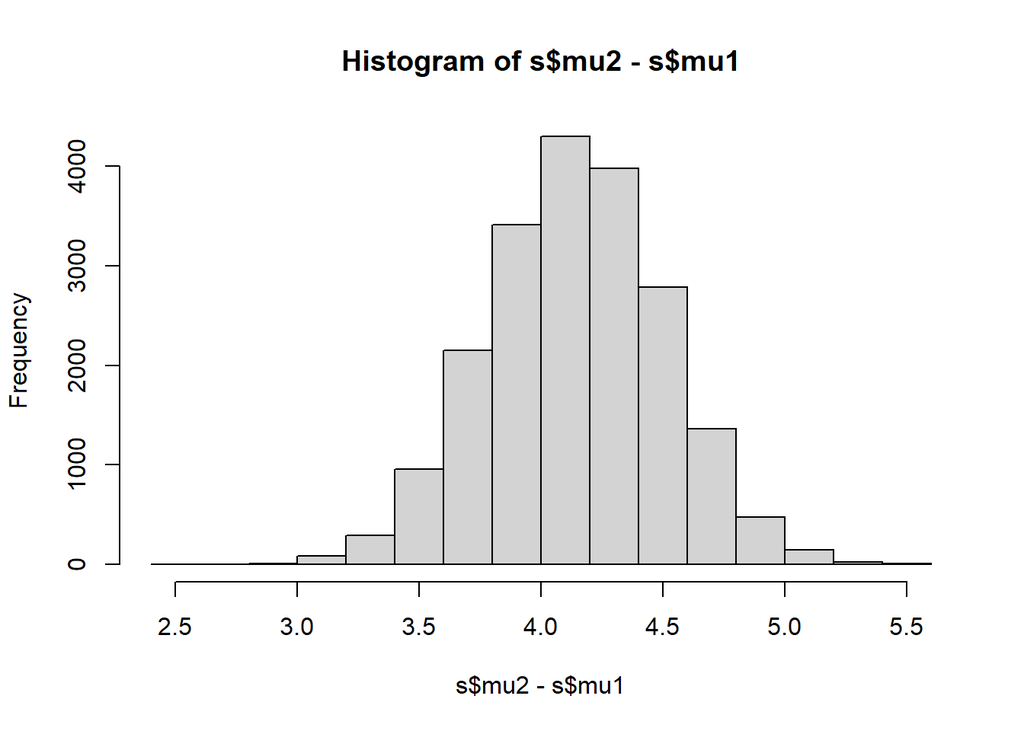

```r
# The above is a short cut for sum(s$theta1 < s$theta2) / nrow(s)

# Plotting distribution of the difference between theta1 and theta2
hist(s$mu2 - s$mu1)
```

**Remarque** : Avec l’histogramme ci-contre et après calcul de la probabilité on peut donc constater que l’instructeur préfère les musiques pas très bruyantes.

## MCMC

## Fake data check

```r
## FAKE DATA CHECK

generate_fake_data <- function(n1,n2) {
  mu1_fake <- -20  # Utiliser la médiane au lieu de la moyenne
  mu2_fake <- -15

  sigma1_fake <- 30
  sigma2_fake <- 40

  # Générer des données factices à partir de la distribution de Poisson
  y1_fake <- rnorm(n1,mu1_fake, sigma1_fake)
  y2_fake <- rnorm(n2,mu2_fake, sigma2_fake)

  return(list(y1_fake = y1_fake, y2_fake = y2_fake))
}

# Générer des données factices à partir des échantillons postérieurs
fake_data <- generate_fake_data(length(loudness_like),length(loudness_dislike))

# # Comparer les données factices avec les données réelles
# summary(fake_data$y1_fake)
# summary(fake_data$y2_fake)
# summary(y1)
# summary(y2)

data_list <- list(y1 = fake_data$y1_fake, y2 = fake_data$y2_fake, n1 = length(fake_data$y1_fake),n2 = length(fake_data$y2_fake))


# Compiling and producing posterior samples from the model.
jags_samples <- run.jags(model = model_string_loudness, data = data_list, monitor = c("mu1", "mu2","sigma1","sigma2"))
```

```
## Compiling rjags model...
## Calling the simulation using the rjags method...
## Adapting the model for 1000 iterations...
## Burning in the model for 4000 iterations...
## Running the model for 10000 iterations...
## Simulation complete
## Calculating summary statistics...
## Calculating the Gelman-Rubin statistic for 4 variables....
## Finished running the simulation
```

```r
# Plotting and summarizing the posterior distribution
jags_samples
```

```
##
## JAGS model summary statistics from 20000 samples (chains = 2; adapt+burnin = 5000):
##
##           Lower95     Median    Upper95       Mean          SD Mode      MCerr
## mu1       -22.286    -18.919    -15.519    -18.927      1.7225   --   0.016038
## mu2       -23.142    -18.108    -13.062    -18.095      2.5757   --   0.023297
## sigma1 0.00095352  0.0011279  0.0013076  0.0011306 0.000090726   -- 6.7718e-07
## sigma2  0.0006231 0.00076544 0.00092483 0.00076824 0.000077431   -- 5.6203e-07
##
##        MC%ofSD SSeff      AC.10   psrf
## mu1        0.9 11536 -0.0013709 1.0007
## mu2        0.9 12223 -0.0030336 1.0008
## sigma1     0.7 17950  -0.001946 1.0002
## sigma2     0.7 18980 -0.0059795      1
##
## Total time taken: 12.8 seconds
```

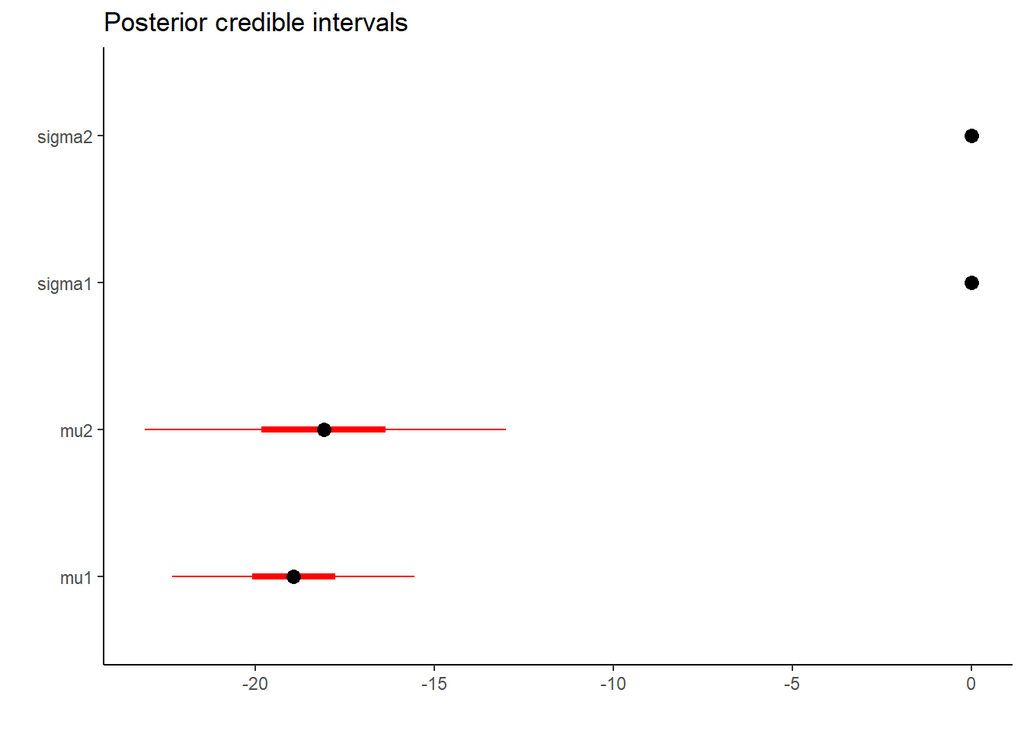

```r
plot_credible_intervals(jags_samples)
```

```r
summary(jags_samples)
```

```
##              Lower95        Median       Upper95          Mean           SD
## mu1    -2.228567e+01 -1.891929e+01 -1.551860e+01 -1.892685e+01 1.722524e+00
## mu2    -2.314241e+01 -1.810759e+01 -1.306169e+01 -1.809463e+01 2.575707e+00
## sigma1  9.535231e-04  1.127926e-03  1.307575e-03  1.130578e-03 9.072640e-05
## sigma2  6.230958e-04  7.654431e-04  9.248343e-04  7.682437e-04 7.743103e-05
##        Mode        MCerr MC%ofSD SSeff        AC.10     psrf
## mu1      NA 1.603754e-02     0.9 11536 -0.001370867 1.000667
## mu2      NA 2.329747e-02     0.9 12223 -0.003033635 1.000805
## sigma1   NA 6.771825e-07     0.7 17950 -0.001945975 1.000203
## sigma2   NA 5.620323e-07     0.7 18980 -0.005979451 1.000012
```

**Conclusion** : je ne sais pas comment interpréter les sigmas

# 5- Variable : mode

**Description :** Mode indique la modalité (majeure ou mineure) d’un piste, le type de gamme à partir de laquelle son contenu mélodique est dérivé. Le majeur est représenté par 1 et le mineur par 0.

## Modèle

```r
model_string_mode <- "
model {
  theta1 ~ dbeta(1, 1)
  theta2 ~ dbeta(1, 1)

  for (i in 1:n1){
    y1[i] ~ dbern(theta1)
  }
  for (i in 1:n2){
    y2[i] ~ dbern(theta2)
  }
}
"


y1 = as.double(mode_like)
y2 = as.double(mode_dislike)

data_list <- list(y1 = y1, y2 = y2, n1=length(y1),n2=length(y2))

jags_samples <- run.jags(model = model_string_mode, data = data_list, monitor = c("theta1","theta2"))
```

```
## Compiling rjags model...
## Calling the simulation using the rjags method...
## Note: the model did not require adaptation
## Burning in the model for 4000 iterations...
## Running the model for 10000 iterations...
## Simulation complete
## Calculating summary statistics...
## Calculating the Gelman-Rubin statistic for 2 variables....
## Finished running the simulation
```

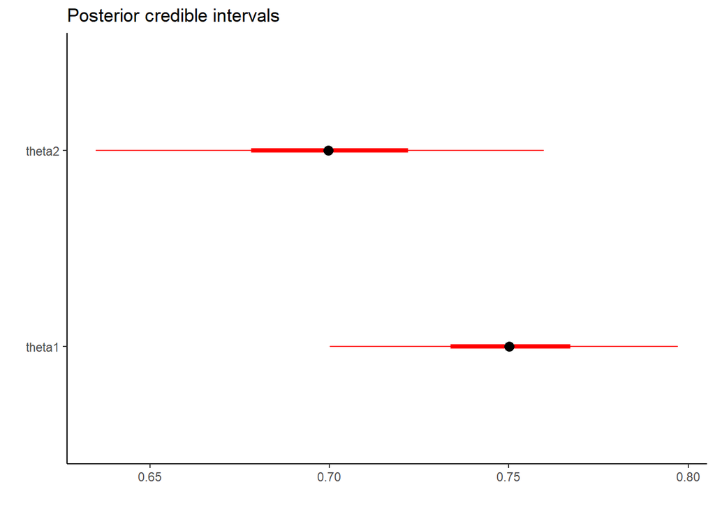

```r
plot_credible_intervals(jags_samples)
```

## Interprétation

## Etude des mcmc

## Fake data check

```r
## FAKE DATA CHECK

generate_fake_data <- function(n1,n2) {
  theta1_fake <- 0.74  # Utiliser la médiane au lieu de la moyenne
  theta2_fake <- 0.5


  # Générer des données factices à partir de la distribution de Poisson
  y1_fake <- rbernoulli(n1,theta1_fake)
  y2_fake <- rbernoulli(n2,theta2_fake)

  return(list(y1_fake = as.double(y1_fake), y2_fake =as.double(y2_fake)))
}

# Générer des données factices à partir des échantillons postérieurs
fake_data <- generate_fake_data(length(mode_like),length(mode_dislike))

# # Comparer les données factices avec les données réelles
# summary(fake_data$y1_fake)
# summary(fake_data$y2_fake)
# summary(y1)
# summary(y2)

data_list <- list(y1 = fake_data$y1_fake, y2 = fake_data$y2_fake, n1=length(y1),n2=length(y2))


# Compiling and producing posterior samples from the model.
jags_samples <- run.jags(model = model_string_mode, data = data_list, monitor = c("theta1", "theta2"))
```

```
## Compiling rjags model...
## Calling the simulation using the rjags method...
## Note: the model did not require adaptation
## Burning in the model for 4000 iterations...
## Running the model for 10000 iterations...
## Simulation complete
## Calculating summary statistics...
## Calculating the Gelman-Rubin statistic for 2 variables....
## Finished running the simulation
```

```r
# Plotting and summarizing the posterior distribution
jags_samples
```

```
##
## JAGS model summary statistics from 20000 samples (chains = 2; adapt+burnin = 5000):
##
##        Lower95  Median Upper95    Mean       SD Mode      MCerr MC%ofSD SSeff
## theta1 0.67376 0.72743 0.77482 0.72681 0.025692   -- 0.00017512     0.7 21524
## theta2 0.42498  0.4946 0.56348 0.49499 0.035493   -- 0.00025508     0.7 19361
##
##              AC.10    psrf
## theta1    0.011696 0.99999
## theta2 -0.00071283       1
##
## Total time taken: 0.9 seconds
```

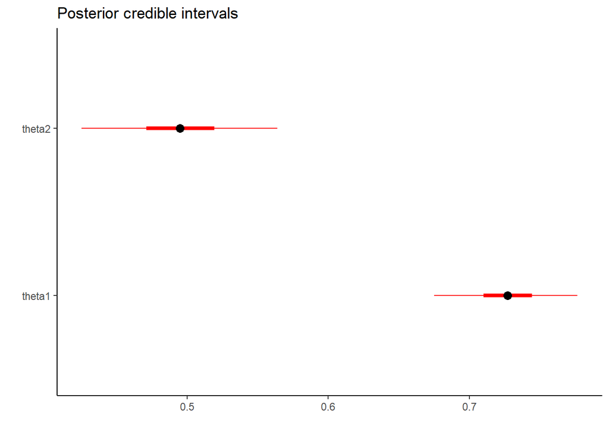

```r
plot_credible_intervals(jags_samples)
```

```r
summary(jags_samples)
```

```
##          Lower95    Median   Upper95      Mean         SD Mode       MCerr
## theta1 0.6737612 0.7274254 0.7748231 0.7268139 0.02569229   NA 0.000175124
## theta2 0.4249777 0.4946000 0.5634800 0.4949931 0.03549307   NA 0.000255079
##        MC%ofSD SSeff        AC.10      psrf
## theta1     0.7 21524  0.011696132 0.9999888
## theta2     0.7 19361 -0.000712825 1.0000235
```

**Conclusion :**

# 6- Variable : speechiness

**Description :** Speechiness détecte la présence de mots prononcés dans une piste.les valeurs supérieures à 0,66 décrivent des morceaux qui sont probablement entièrement constitués de paroles mots. Les valeurs comprises entre 0,33 et 0,66 décrivent des pistes qui peut contenir à la fois de la musique et de la parole, soit en sections, soit en couches, y compris des cas tels que la musique rap. Valeurs ci-dessous 0,33 représente très probablement la musique et d’autres éléments non vocaux.

## Modèle

```r
# Spécifier le modèle JAGS
model_string_speechiness <- "
model {
  # Number of successes
  for (i in 1:n1){
    y1[i] ~ dgamma(alpha1,beta1)
  }
  for (i in 1:n2){
    y2[i] ~ dgamma(alpha2,beta2)
  }

  alpha1 ~ dgamma(2,0.8)
  alpha2 ~ dgamma(2,0.8)

  beta1 ~ dgamma(2,0.8)
  beta2 ~ dgamma(2,0.8)
}
"
y1=speechiness_like
y2=speechiness_dislike

# Créer une liste de données pour JAGS
data_list <- list(y1 = y1, y2 = y2,n1 = length(y1), n2 = length(y2) )

# Exécuter le modèle et extraire les échantillons postérieurs
jags_samples <- run.jags(model = model_string_speechiness, data = data_list, monitor = c("alpha1", "alpha2","beta1","beta2"))
```

```
## Compiling rjags model...
## Calling the simulation using the rjags method...
## Adapting the model for 1000 iterations...
## Burning in the model for 4000 iterations...
## Running the model for 10000 iterations...
## Simulation complete
## Calculating summary statistics...
## Calculating the Gelman-Rubin statistic for 4 variables....
## Finished running the simulation
```

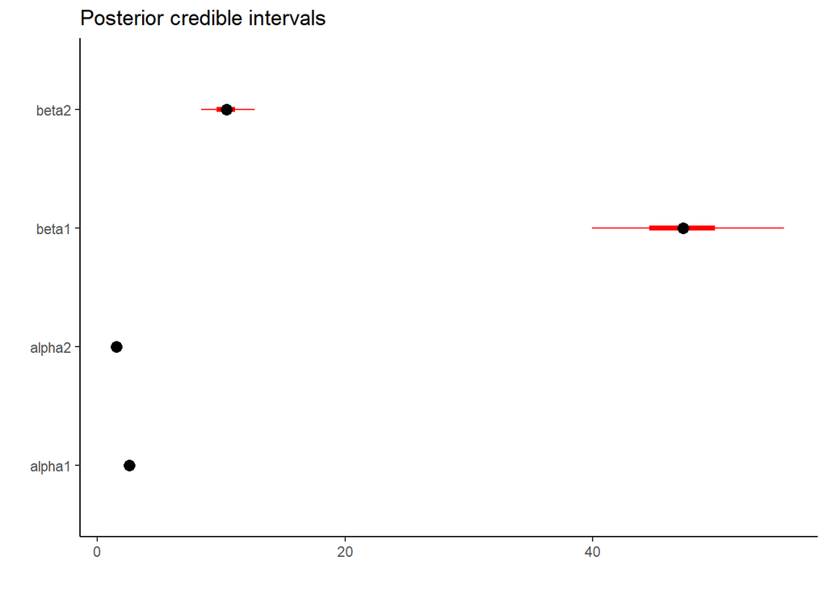

```r
# Visualiser les résultats
plot_credible_intervals(jags_samples)
```

## Interprétation

```r
s <- as.data.frame(jags_samples$mcmc %>% lapply(as_tibble) %>% bind_rows())

# The probability that the rate theta1 is smaller than theta2
mean(s$beta1 < s$beta2)
```

```
## [1] 0
```

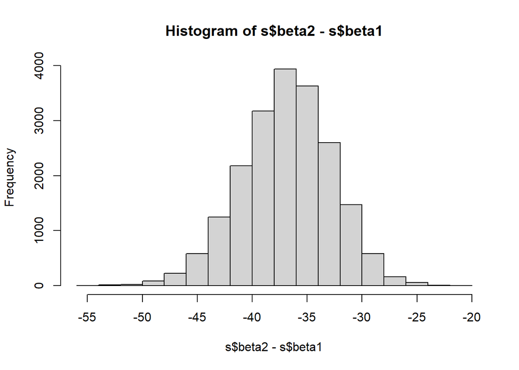

```r
# The above is a short cut for sum(s$theta1 < s$theta2) / nrow(s)

# Plotting distribution of the difference between theta1 and theta2
hist(s$beta2 - s$beta1)
```

```r
# The probability that the rate theta1 is smaller than theta2
mean(s$alpha1 < s$alpha2)
```

```
## [1] 0
```

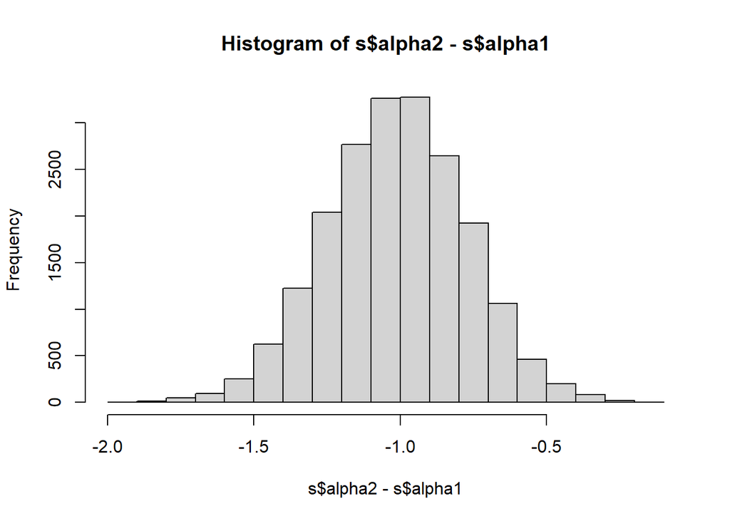

```r
# The above is a short cut for sum(s$theta1 < s$theta2) / nrow(s)

# Plotting distribution of the difference between theta1 and theta2
hist(s$alpha2 - s$alpha1)
```

## Etude des mcmc

## Fake data check

```r
## FAKE DATA CHECK

generate_fake_data <- function(n1,n2) {
  alpha1_fake <- 2  # Utiliser la médiane au lieu de la moyenne
  alpha2_fake <- 1.5

  beta1_fake <- 10
  beta2_fake <- 40

  # Générer des données factices à partir de la distribution de Poisson
  y1_fake <- rgamma(n1,alpha1_fake, beta1_fake)
  y2_fake <- rgamma(n2,alpha2_fake, beta2_fake)

  return(list(y1_fake = y1_fake, y2_fake = y2_fake))
}

# Générer des données factices à partir des échantillons postérieurs
fake_data <- generate_fake_data(length(speechiness_like),length(speechiness_dislike))

data_list <- list(y1 = fake_data$y1_fake, y2 = fake_data$y2_fake, n1 = length(y1), n2 = length(y2))


# Compiling and producing posterior samples from the model.
jags_samples <- run.jags(model = model_string_speechiness, data = data_list, monitor = c("alpha1", "alpha2","beta1","beta2"))
```

```
## Compiling rjags model...
## Calling the simulation using the rjags method...
## Adapting the model for 1000 iterations...
## Burning in the model for 4000 iterations...
## Running the model for 10000 iterations...
## Simulation complete
## Calculating summary statistics...
## Calculating the Gelman-Rubin statistic for 4 variables....
## Finished running the simulation
```

```r
# Plotting and summarizing the posterior distribution
jags_samples
```

```
##
## JAGS model summary statistics from 20000 samples (chains = 2; adapt+burnin = 5000):
##
##        Lower95 Median Upper95   Mean      SD Mode     MCerr MC%ofSD SSeff
## alpha1  1.6376 1.9057  2.1948  1.909 0.14314   -- 0.0031639     2.2  2047
## alpha2  1.0492 1.2575  1.4817  1.261 0.11124   -- 0.0020239     1.8  3021
## beta1   7.7909 9.2759    10.9 9.2912 0.79521   --  0.017282     2.2  2117
## beta2    25.25 31.814  38.623  31.91  3.4278   --  0.058979     1.7  3378
##
##           AC.10   psrf
## alpha1  0.11557 1.0007
## alpha2  0.06477 1.0002
## beta1    0.1066 1.0004
## beta2  0.048448 1.0001
##
## Total time taken: 35.8 seconds
```

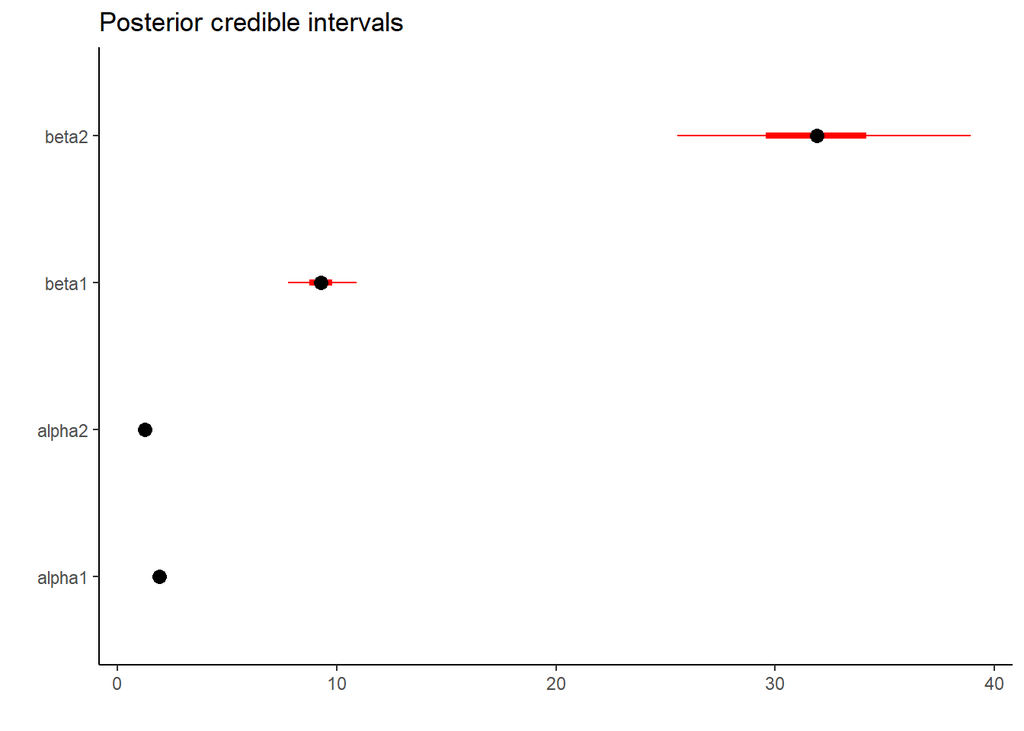

```r
plot_credible_intervals(jags_samples)
```

```r
summary(jags_samples)
```

```
##          Lower95    Median   Upper95      Mean        SD Mode       MCerr
## alpha1  1.637562  1.905735  2.194822  1.908996 0.1431424   NA 0.003163936
## alpha2  1.049177  1.257540  1.481724  1.261043 0.1112396   NA 0.002023927
## beta1   7.790881  9.275946 10.899569  9.291151 0.7952069   NA 0.017282006
## beta2  25.250253 31.814489 38.622843 31.909649 3.4277600   NA 0.058978570
##        MC%ofSD SSeff      AC.10     psrf
## alpha1     2.2  2047 0.11557090 1.000651
## alpha2     1.8  3021 0.06477024 1.000247
## beta1      2.2  2117 0.10659751 1.000409
## beta2      1.7  3378 0.04844754 1.000109
```

**Conclusion :**

# 7- Variable : acousticness

**description** A confidence measure from 0.0 to 1.0 of whether the track is acoustic. 1.0 represents high confidence the track is acoustic.

En observant les datas, je suppose que l’accousticness des disliked suivent une beta, la distribution des likes comme cuvette applatie fit avec une loi beta où $\alpha=\beta\le 1$.

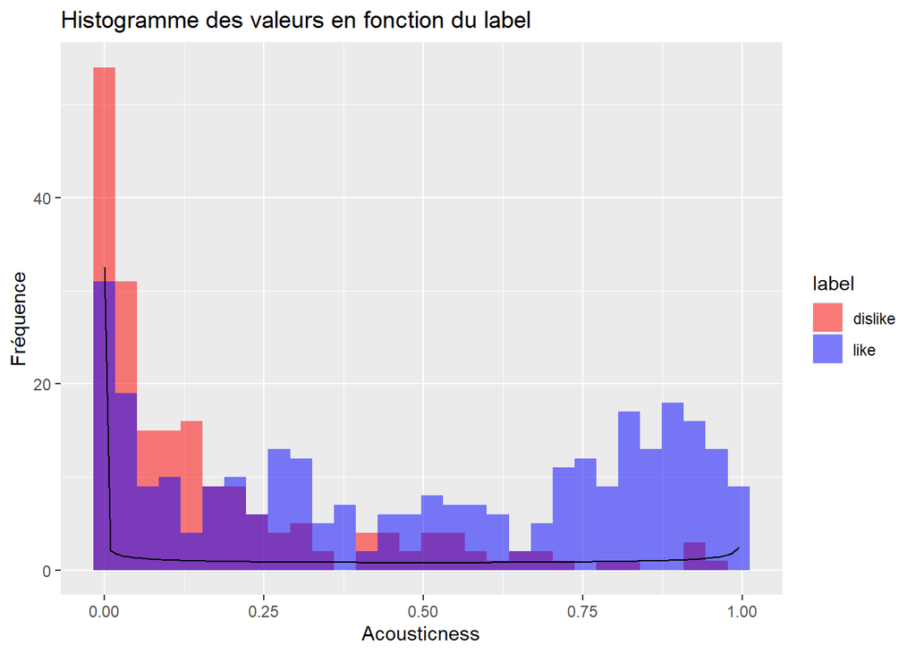

```r
beta_density <- function(x, alpha, beta) {
  dbeta(x, shape1 = alpha, shape2 = beta)
}

ggplot(data, aes(x = acousticness, fill = label)) +
    geom_histogram(alpha = 0.5, position = "identity", bins = 30) +
    stat_function(fun = beta_density, args = list(alpha = 0.7, beta = 0.7), color = "black") +
    labs(title = "Histogramme des valeurs en fonction du label",
         x = "Acousticness",
         y = "Fréquence") +
    scale_fill_manual(values = c("red", "blue"))  # Définir les couleurs pour chaque label
```

## Modèle

```r
model_string_acc <- "
model {
  alpha1 ~ dunif(0,2);
  alpha2 ~ dunif(0,2);
  beta1 ~ dunif(0,2);
  beta2 ~ dunif(0,2);
  for (i in 1:n1) {
    y1[i] ~ dbeta(alpha1,beta1);
  }

  for (i in 1:n2) {
    y2[i] ~ dbeta(alpha2,beta2);
  }
}
"


data_list_acc <- list(y1 = acousticness_like, y2 = acousticness_dislike,
                  n1 = length(y1), n2 = length(y2))

# Compiling and producing posterior samples from the model.
jags_samples <- run.jags(model = model_string_acc, data = data_list_acc, monitor = c("alpha1","alpha2", "beta1","beta2"))
```

```
## Compiling rjags model...
## Calling the simulation using the rjags method...
## Adapting the model for 1000 iterations...
## Burning in the model for 4000 iterations...
## Running the model for 10000 iterations...
## Simulation complete
## Calculating summary statistics...
## Calculating the Gelman-Rubin statistic for 4 variables....
## Finished running the simulation
```

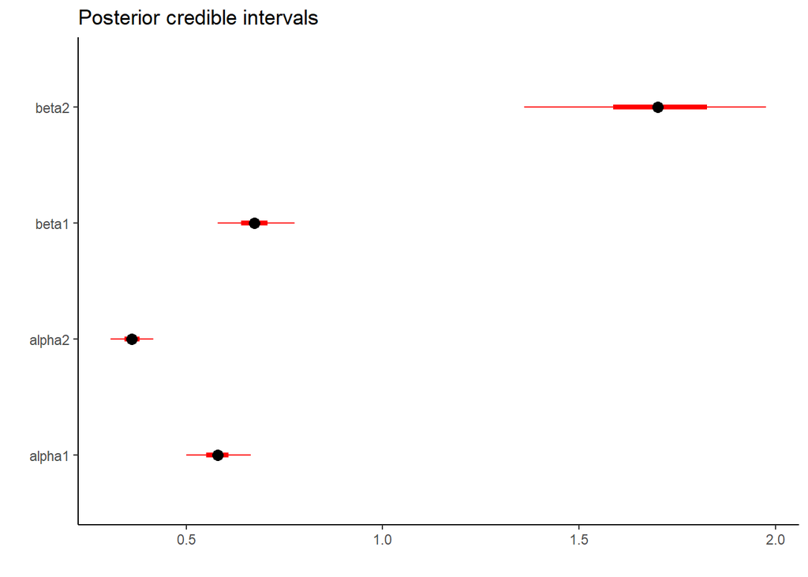

```r
plot_credible_intervals(jags_samples)
```